# Day 2: Logistic regression and MCMC

Author

Masatoshi Katabuchi

Published

October 22, 2026

# Seedling survival regression

## Model and data

We model seedling survival for a single tree species across 60 simulated quadrats using binomial logistic regression:

$$s_i \sim \operatorname{Binomial}(n_i,p_i), \qquad
\operatorname{logit}(p_i)=\alpha+\beta x_i.$$

- $i$: quadrat (`quadrat`)
- $n_i$: number of seedlings (`n`)
- $s_i$: number of surviving seedlings (`suv`)
- $p_i$: survival probability
- $x_i$: scaled conspecific density (`cons`)

We assign independent $\operatorname{Normal}(0, 2.5)$ priors to $\alpha$ and $\beta$.

We use prepared posterior samples to examine MCMC diagnostics, estimate model parameters, and visualize the relationship between density and survival.

### Packages and data

```r
library(tidyverse)
library(posterior)
library(bayesplot)
library(here)
theme_set(theme_bw(base_size = 14))

ndd <- read_csv(here("data", "ndd.csv"))
```

## Fitting the model with Stan

The model in `stan/logit_reg.stan` combines priors and likelihood:

```stan
model {
  alpha ~ normal(0, 2.5);
  beta ~ normal(0, 2.5);
  suv ~ binomial_logit(n, alpha + beta * cons);
}
```

The first two statements specify the priors; the third specifies the likelihood. Stan uses MCMC to sample from the posterior distribution.

The following code illustrates how cmdstanr runs the model; it is shown here without execution.

```r
model_stan <- cmdstanr::cmdstan_model(
  here("stan", "logit_reg.stan")
)

fit_stan <- model_stan$sample(
  data = stan_data,
  chains = 4
)
```

`cmdstan_model()` compiles the Stan model; `$sample()` runs four MCMC chains. `stan_data` contains the data passed to Stan and is constructed in the optional appendix.

For this lesson, we use previously saved posterior samples instead of fitting the model again.

## Load prepared posterior samples

```r
fit <- readRDS(here("fits", "day2_ndd.rds"))
coef_draws <- subset_draws(fit$draws, variable = c("alpha", "beta"))
sampler_diagnostics <- fit$diagnostics
```

The prepared result uses the supplied, unchanged `ndd.csv`. Coefficient draws retain their chain and iteration identifiers; diagnostics are from the same fit. If the data or model are changed, new inference is required.

## Trace plots

First inspect how the chains explore the posterior.

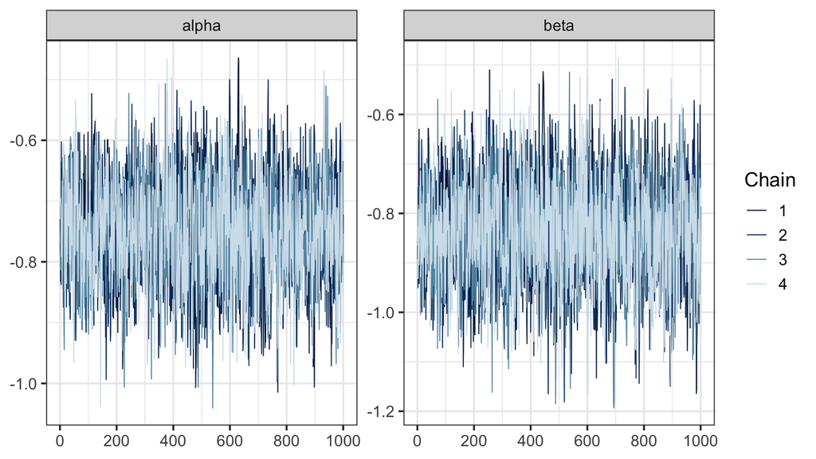

```r
bayesplot::mcmc_trace(coef_draws, pars = c("alpha", "beta"))
```

The horizontal axis is saved sampling step, the vertical axis is a coefficient, and colours identify chains. These are post-warmup samples.

The prepared result’s chains cover similar ranges without persistent separation or drift. Overlap alone does not establish convergence; a single jump alone does not indicate failure.

Next, use numerical diagnostics to check sampling quality alongside these traces.

## Numerical diagnostics

```r
sampling_table <- posterior::summarise_draws(
  coef_draws,
  rhat = posterior::rhat,
  ess_bulk = posterior::ess_bulk,
  ess_tail = posterior::ess_tail
)
sampling_table
```

```
#> # A tibble: 2 × 4
#>   variable  rhat ess_bulk ess_tail
#>   <chr>    <dbl>    <dbl>    <dbl>
#> 1 alpha     1.00    1854.    2260.
#> 2 beta      1.00    2066.    2228.
```

```r
# One row per chain, recorded when the model was fitted.
sampler_table <- as_tibble(sampler_diagnostics) |>
  mutate(chain = row_number(), .before = 1)
sampler_table
```

```
#> # A tibble: 4 × 4
#>   chain num_divergent num_max_treedepth ebfmi
#>   <int>         <dbl>             <int> <dbl>
#> 1     1             0                 0  1.11
#> 2     2             0                 0  1.08
#> 3     3             0                 0  1.05
#> 4     4             0                 0  1.03
```

- **`rhat`:** Agreement across chains. Values should be close to 1 (ideally below 1.01).
- **`ess_bulk`, `ess_tail`:** Effective sample sizes for the main part and tails of the posterior. Larger values are better; 400 is a useful minimum guideline here.
- **`num_divergent`:** Number of divergent transitions, where the sampler fails to accurately follow a trajectory. Ideally zero.

The prepared fit has R-hat near 1, ESS above 400, and no divergences, suggesting satisfactory sampling. However, good MCMC diagnostics do not guarantee that the ecological model is appropriate.

## Posterior summary and coefficient interpretation

`summarise_draws()` produces the coefficient table. The requested 2.5th and 97.5th percentiles give a **95% credible interval**, containing the central 95% of posterior probability for each coefficient, conditional on the data and model (including its priors).

```r
coefficient_table <- posterior::summarise_draws(
  coef_draws,
  mean = mean,
  sd = sd,
  \(x) quantile(x, probs = c(0.025, 0.975))
)
coefficient_table
```

```
#> # A tibble: 2 × 5
#>   variable   mean     sd `2.5%` `97.5%`
#>   <chr>     <dbl>  <dbl>  <dbl>   <dbl>
#> 1 alpha    -0.750 0.0850 -0.918  -0.587
#> 2 beta     -0.837 0.105  -1.04   -0.631
```

| Column | Meaning |
| --- | --- |
| `variable` | `alpha`: intercept; `beta`: density coefficient. |
| `mean` | Posterior mean of the coefficient. |
| `sd` | Posterior standard deviation: uncertainty about the coefficient. |
| `2.5%`, `97.5%` | Lower and upper ends of the 95% credible interval. |

$\alpha$ is log-odds at `cons = 0`. $\beta$ is the change in log-odds per one-unit increase in the scaled density index (one SD on its generating scale). Neither coefficient is itself a probability; the change in survival probability depends on the starting density.

In the prepared result, `beta` is negative and its credible interval excludes zero: higher density is associated with lower survival probability under this model. This is an association in simulated data, not evidence of a causal mechanism.

## Posterior survival probabilities

**Posterior coefficient draws → Posterior survival curves → Median and 95% credible interval**

`density_grid` contains 81 equally spaced values spanning the observed range of conspecific density. These are prediction points, not additional observations; they let us draw smooth survival probability curves.

For each paired draw of $\alpha$ and $\beta$, `plogis(alpha + beta * cons)` gives survival probabilities across this grid.

```r
density_grid <- tibble(
  cons = seq(min(ndd$cons), max(ndd$cons), length.out = 81)
)

curve_draws <- as_tibble(coef_draws) |>
  select(.draw, alpha, beta) |>
  crossing(density_grid) |>
  mutate(p = plogis(alpha + beta * cons))
```

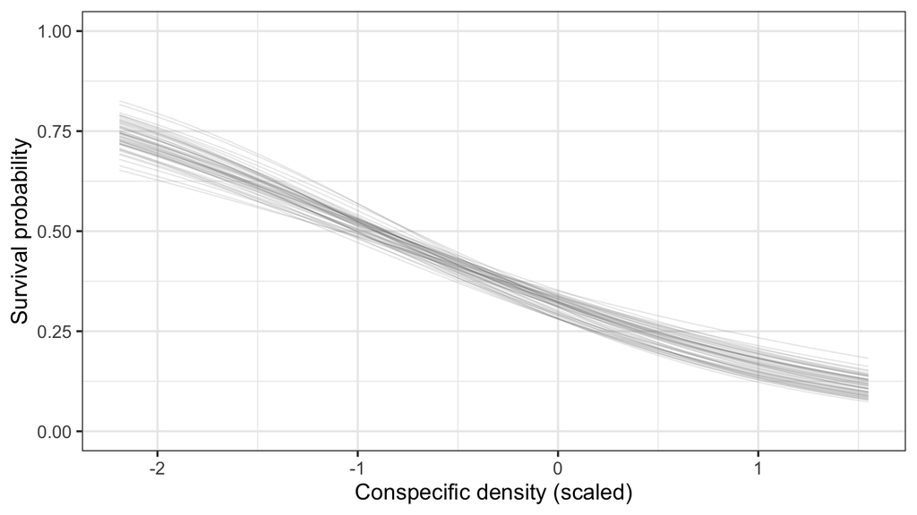

```r
set.seed(42)
selected_draws <- curve_draws |>
  distinct(.draw) |>
  slice_sample(n = 50)

posterior_curves_plot <- curve_draws |>
  semi_join(selected_draws, by = ".draw") |>
  ggplot(aes(x = cons, y = p, group = .draw)) +
  geom_line(colour = "grey40", alpha = 0.15, linewidth = 0.4) +
  scale_y_continuous(limits = c(0, 1)) +
  labs(x = "Conspecific density (scaled)", y = "Survival probability")
posterior_curves_plot
```

Each line represents one possible survival curve based on a posterior draw of the intercept and slope. The variation among curves illustrates uncertainty in the estimated relationship.

Using **all posterior draws**, we now summarize survival probabilities at each density value:

- **Median:** the central estimate of survival probability.
- **2.5th and 97.5th percentiles:** the pointwise 95% credible interval.

```r
curve_summary <- curve_draws |>
  group_by(cons) |>
  summarise(
    median = median(p),
    lower = quantile(p, 0.025),
    upper = quantile(p, 0.975),
    .groups = "drop"
  )
```

The next plot shows these medians and credible intervals alongside the observed survival proportions.

**Important:** We keep $\alpha$ and $\beta$ paired within each posterior draw to preserve their joint uncertainty. The credible interval represents uncertainty in the estimated survival probability, not variation among individual seedlings.

## Regression plot and interpretation

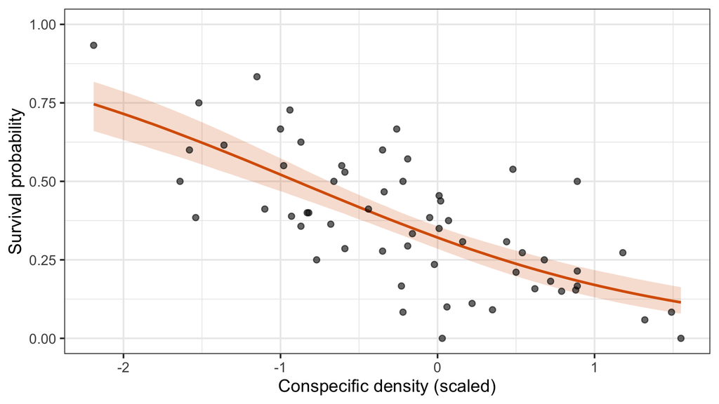

```r
regression_plot <- ggplot(curve_summary, aes(x = cons)) +
  geom_ribbon(aes(ymin = lower, ymax = upper), fill = "#d95f02", alpha = 0.2) +
  geom_line(aes(y = median), colour = "#d95f02", linewidth = 1) +
  geom_point(data = ndd, aes(y = suv / n), alpha = 0.6) +
  scale_y_continuous(limits = c(0, 1)) +
  labs(x = "Conspecific density (scaled)", y = "Survival probability")
regression_plot
```

- **Line:** posterior median of survival probability.
- **Ribbon:** 95% credible interval for survival probability at each density.
- **Points:** observed survivor proportions, one per quadrat.

For the prepared result, the fitted curve decreases with density, consistent with the negative coefficient. The ribbon describes uncertainty about probability; it need not contain every observed proportion. Observed proportions also vary because survival is binomial. These are **pointwise** credible intervals, not a simultaneous band for the whole curve. A posterior predictive interval for survivor counts or proportions would also include binomial sampling variability.

The `alpha` argument in `geom_ribbon()` controls transparency; it is unrelated to the regression intercept $\alpha$.

Sampling diagnostics tell us about computation; they do not establish that the ecological model is appropriate.

The result sheet provides the same outputs without the code.

# Optional appendix: Fitting models with brms and cmdstanr

The examples below run **new inference** and require a prepared fitting environment. They are displayed but not executed during rendering. Students do not need to install CmdStan, a C++ toolchain or Docker on their own computers. The core walkthrough ends above; this appendix can be omitted during class.

## Fit with brms

`brms` translates the regression formula into Stan. This fits a binomial logit model with Normal(0, 2.5) priors for the internally centered intercept and slope.

```r
library(brms)

fit_brms <- brm(
  suv | trials(n) ~ cons,
  data = ndd,
  family = binomial(link = "logit"),
  prior = c(
    prior(normal(0, 2.5), class = "Intercept"),
    prior(normal(0, 2.5), class = "b")
  ),
  backend = "cmdstanr",
  seed = 42,
  chains = 4,
  cores = 1,
  iter = 2000,
  warmup = 1000,
  refresh = 500
)
```

`trials(n)` supplies the seedling count. `cons` predicts survival on the logit scale. The intercept is included automatically. The coefficient names in brms are `b_Intercept` and `b_cons`.

brms applies its intercept prior at `mean(cons)`; the Stan model below applies its intercept prior at `cons = 0`. The likelihood is the same, but these prior specifications differ. See the [brms prior documentation](https://paulbuerkner.com/brms/reference/set_prior.html).

## Fit with cmdstanr

The supplied file `stan/logit_reg.stan` contains:

```stan
data {
  int<lower=0> N;               // number of quadrats
  array[N] int<lower=0> n;      // seedlings per quadrat
  array[N] int<lower=0> suv;    // survivors per quadrat
  vector[N] cons;               // conspecific density (scaled)
}

parameters {
  real alpha;                   // intercept (logit scale)
  real beta;                    // slope (logit scale)
}

model {
  // likelihood: logit(p) = alpha + beta * cons
  suv ~ binomial_logit(n, alpha + beta * cons);
  // priors
  alpha ~ normal(0, 2.5);
  beta ~ normal(0, 2.5);
}
```

The R data list connects the CSV columns to Stan’s data block. `cmdstan_model()` compiles the model, and `$sample()` runs the chains.

```r
library(cmdstanr)

stan_data <- list(
  N = nrow(ndd),
  n = as.integer(ndd$n),
  suv = as.integer(ndd$suv),
  cons = ndd$cons
)

model_stan <- cmdstan_model(here("stan", "logit_reg.stan"))
fit_stan <- model_stan$sample(
  data = stan_data,
  seed = 42,
  chains = 4,
  parallel_chains = 1,
  iter_warmup = 1000,
  iter_sampling = 1000,
  refresh = 500
)
```

## Analyse a newly fitted model

After fitting **one** model, run its matching chunk below in place of the prepared-result loading chunk. Then rerun the core analysis from Trace plots through the regression plot. Each chunk retains chain and iteration identifiers and uses diagnostics from the same fit as the coefficient draws. Do not reload the prepared result when analysing a new fit.

### brms result

```r
coef_draws <- as_draws_df(fit_brms, variable = c("b_Intercept", "b_cons")) |>
  rename_variables(alpha = "b_Intercept", beta = "b_cons")

sampler_diagnostics <- brms::nuts_params(fit_brms) |>
  filter(Parameter == "divergent__") |>
  summarise(num_divergent = sum(Value), .by = Chain) |>
  select(num_divergent)
```

The coefficients are renamed alpha and beta to match the equations. `nuts_params()` supplies the sampler diagnostics; here we count divergences per chain.

### Stan result

```r
coef_draws <- as_draws_df(fit_stan$draws(c("alpha", "beta")))
sampler_diagnostics <- fit_stan$diagnostic_summary()
```

New Stan fits can differ from the prepared result because of Monte Carlo variation; the brms fit also uses the different intercept prior described above. Interpret new fits using their own summaries, diagnostics and traces.

# Instructor reference

Spend at most 2–3 minutes on Fitting the model with Stan: connect priors and likelihood to MCMC draws, then load the prepared samples. The preview is illustrative (`eval=FALSE`); do not compile or fit during this walkthrough. The complete data list and fitting examples remain in the appendix.

Follow the code and outputs in order: traces, numerical diagnostics, coefficient summary, probability calculation and plotting. This is a guided walkthrough, not a worksheet with separate questions, written answers or timed tasks. Explain the coefficient rows and table columns after checking sampling, then connect beta’s sign and uncertainty to the curve.

The coefficient mean is not MLE or MAP, and posterior SD is not Monte Carlo standard error. The plot uses a posterior median; neither summary needs to represent one sampled coefficient pair. Its credible intervals are pointwise, not a simultaneous interval for the entire curve or a predictive interval for survivor counts. Do not summarise alpha and beta separately before transforming.

The root exercise uses CmdStan `$summary()` and brms `summary()`. Our stored file is a list of posterior draws and diagnostics, so `summarise_draws()` supplies the corresponding coefficient table. `summary(fit)` would describe the list. The prepared result corresponds to the supplied CSV and Stan model. If either is changed, fit the changed model rather than reusing the prepared result.

Retain the complete sampler diagnostic output for validation. `num_max_treedepth` counts transitions reaching the tree-depth limit; reaching it can reduce sampling efficiency. `ebfmi` (E-BFMI) checks exploration of the energy distribution; low values warrant investigation. Also check `lp__` and Monte Carlo precision for the intended quantities. Do not copy the root file’s automatic good/bad classifications or its E-BFMI quality scale. Computation and ecological model appropriateness are different issues. The lecture includes one existing PPC figure; predictive simulation details remain optional reference.

## Choosing the fitting route

Use either live fitting section when the prepared environment and class pace permit. For a new fit, use its matching result-loading chunk in place of the prepared result, then rerun the core summaries and plots. Only the prepared result is executed when rendering the handout; live-result chunks have `eval=FALSE`. Do not use stored diagnostics to validate a new fit.

The plain brms formula uses internal predictor centering. Its independent priors are on the centered intercept and slope. If $m$ is the sample mean of cons, that intercept is $\alpha + \beta m$, whereas the Stan model places independent priors directly on $\alpha$ and $\beta$. Here $m$ is approximately -0.191, not zero, so the joint priors differ. The returned `b_Intercept` is nevertheless on the original predictor scale (cons=0). Do not describe differences between these fitting routes as Monte Carlo variation alone or treat the prepared Stan result as a stored brms fit. The likelihood, data and downstream coefficient interpretations remain the same.

The brms result-loading chunk shows only divergence counts. Check treedepth, E-BFMI and other sampler details using the complete `nuts_params(fit_brms)` output when needed. In normal-prior R/Stan syntax, 2.5 is an SD. Rendering never compiles or samples the two fitting sections. No local student toolchain installation is required; validate any classroom live-fitting environment ahead of class. Compilation time and simultaneous server load are separate concerns.

References: [brms formulas](https://paulbuerkner.com/brms/reference/brmsformula.html), [brms draws](https://paulbuerkner.com/brms/reference/draws-brms.html), [posterior summaries](https://mc-stan.org/posterior/reference/draws_summary.html) and [Stan diagnostic guidance](https://mc-stan.org/learn-stan/diagnostics-warnings.html).